# Analysis of Concrete Slump

Yangwei Yan

May 17, 2019

```r
# read data
slump = read.csv(
  url('https://archive.ics.uci.edu/ml/machine-learning-databases/concrete/slump/slump_test.data'),
  header = FALSE,
  skip = 1,
  col.names = c('no','cement','slag','fly_ash','water','sp','coarse_aggr','fine_aggr','slump','flow','compressive_strength'))

slump = select(slump, -no)
```

### Exploratory data analysis (EDA)

1. Summary table

```r
#summary_result = Hmisc::describe(slump)
pander::pander(summary(slump))
```

Table continues below

| cement | slag | fly_ash | water | sp |
| --- | --- | --- | --- | --- |
| Min. :137.0 | Min. : 0.00 | Min. : 0.0 | Min. :160.0 | Min. : 4.40 |
| 1st Qu.:152.0 | 1st Qu.: 0.05 | 1st Qu.:115.5 | 1st Qu.:180.0 | 1st Qu.: 6.00 |
| Median :248.0 | Median :100.00 | Median :164.0 | Median :196.0 | Median : 8.00 |
| Mean :229.9 | Mean : 77.97 | Mean :149.0 | Mean :197.2 | Mean : 8.54 |
| 3rd Qu.:303.9 | 3rd Qu.:125.00 | 3rd Qu.:235.9 | 3rd Qu.:209.5 | 3rd Qu.:10.00 |
| Max. :374.0 | Max. :193.00 | Max. :260.0 | Max. :240.0 | Max. :19.00 |

Table continues below

| coarse_aggr | fine_aggr | slump | flow |
| --- | --- | --- | --- |
| Min. : 708.0 | Min. :640.6 | Min. : 0.00 | Min. :20.00 |
| 1st Qu.: 819.5 | 1st Qu.:684.5 | 1st Qu.:14.50 | 1st Qu.:38.50 |
| Median : 879.0 | Median :742.7 | Median :21.50 | Median :54.00 |
| Mean : 884.0 | Mean :739.6 | Mean :18.05 | Mean :49.61 |
| 3rd Qu.: 952.8 | 3rd Qu.:788.0 | 3rd Qu.:24.00 | 3rd Qu.:63.75 |
| Max. :1049.9 | Max. :902.0 | Max. :29.00 | Max. :78.00 |

| compressive_strength |
| --- |
| Min. :17.19 |
| 1st Qu.:30.90 |
| Median :35.52 |
| Mean :36.04 |
| 3rd Qu.:41.20 |
| Max. :58.53 |

2. Boxplot for each variable

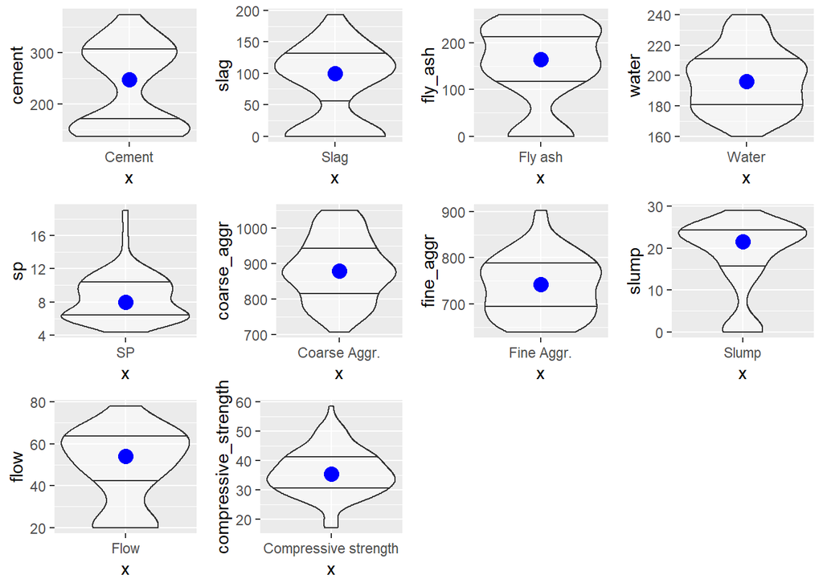

```r
g = list()
g[[1]] = slump %>%
    ggplot(aes(x = "Cement", y = cement)) +
    geom_violin(alpha = 0.5,draw_quantiles = c(0.25,0.75)) +
    stat_summary(fun.y = median, geom = "point", color = "blue", size = 4)
g[[2]] = slump %>%
    ggplot(aes(x = "Slag", y = slag)) +
    geom_violin(alpha = 0.5,draw_quantiles = c(0.25,0.75)) +
    stat_summary(fun.y = median, geom = "point", color = "blue", size = 4)
g[[3]] = slump %>%
    ggplot(aes(x = "Fly ash", y = fly_ash)) +
    geom_violin(alpha = 0.5,draw_quantiles = c(0.25,0.75)) +
    stat_summary(fun.y = median, geom = "point", color = "blue", size = 4)
g[[4]] = slump %>%
    ggplot(aes(x = "Water", y = water)) +
    geom_violin(alpha = 0.5,draw_quantiles = c(0.25,0.75)) +
    stat_summary(fun.y = median, geom = "point", color = "blue", size = 4)
g[[5]] = slump %>%
    ggplot(aes(x = "SP", y = sp)) +
    geom_violin(alpha = 0.5,draw_quantiles = c(0.25,0.75)) +
    stat_summary(fun.y = median, geom = "point", color = "blue", size = 4)
g[[6]] = slump %>%
    ggplot(aes(x = "Coarse Aggr.", y = coarse_aggr)) +
    geom_violin(alpha = 0.5,draw_quantiles = c(0.25,0.75)) +
    stat_summary(fun.y = median, geom = "point", color = "blue", size = 4)
g[[7]] = slump %>%
    ggplot(aes(x = "Fine Aggr.", y = fine_aggr)) +
    geom_violin(alpha = 0.5,draw_quantiles = c(0.25,0.75)) +
    stat_summary(fun.y = median, geom = "point", color = "blue", size = 4)
g[[8]] = slump %>%
    ggplot(aes(x = "Slump", y = slump)) +
    geom_violin(alpha = 0.5,draw_quantiles = c(0.25,0.75)) +
    stat_summary(fun.y = median, geom = "point", color = "blue", size = 4)
g[[9]] = slump %>%
    ggplot(aes(x = "Flow", y = flow)) +
    geom_violin(alpha = 0.5,draw_quantiles = c(0.25,0.75)) +
    stat_summary(fun.y = median, geom = "point", color = "blue", size = 4)
g[[10]] = slump %>%
    ggplot(aes(x = "Compressive strength", y = compressive_strength)) +
    geom_violin(alpha = 0.5,draw_quantiles = c(0.25,0.75)) +
    stat_summary(fun.y = median, geom = "point", color = "blue", size = 4)

grid.arrange(grobs = g, ncol = 4)
```

- Compressive strength, Coarse Aggr. are normally distributed variables, while cement, slag, fly ash, sp, slump, flow are all skewed, not symmetricly distributed.
- I plotted the violin plot. The blue point is the median value of the variable, the two lines in the box indicate 25% and 75% quantiles. The width of the boxes show the probability density of the data at different values. As the volin plots suggest, several variables such as cement, slag show multi-mode distributions.
- Since strong skewness is observed for several variables, the log-transformation might help. In addition, to deal with multi-mode distribution, it might be helpful to perform analysis using stratification or transform the continous variables into categorical variables.

### Relationship between 28-day compressive strength (CS) and the seven input measurement features.

```r
# stratify CS into 4 categories
slump = slump %>%
  mutate(cs_bin = ifelse(compressive_strength<=30, '<=30', ifelse(compressive_strength>30 & compressive_strength<=35, '30-35', ifelse(compressive_strength>35 & compressive_strength<=40, '35-40', '>40')))) %>%
  mutate(cs_bin = factor(cs_bin,levels = c('<=30','30-35','35-40','>40')))
```

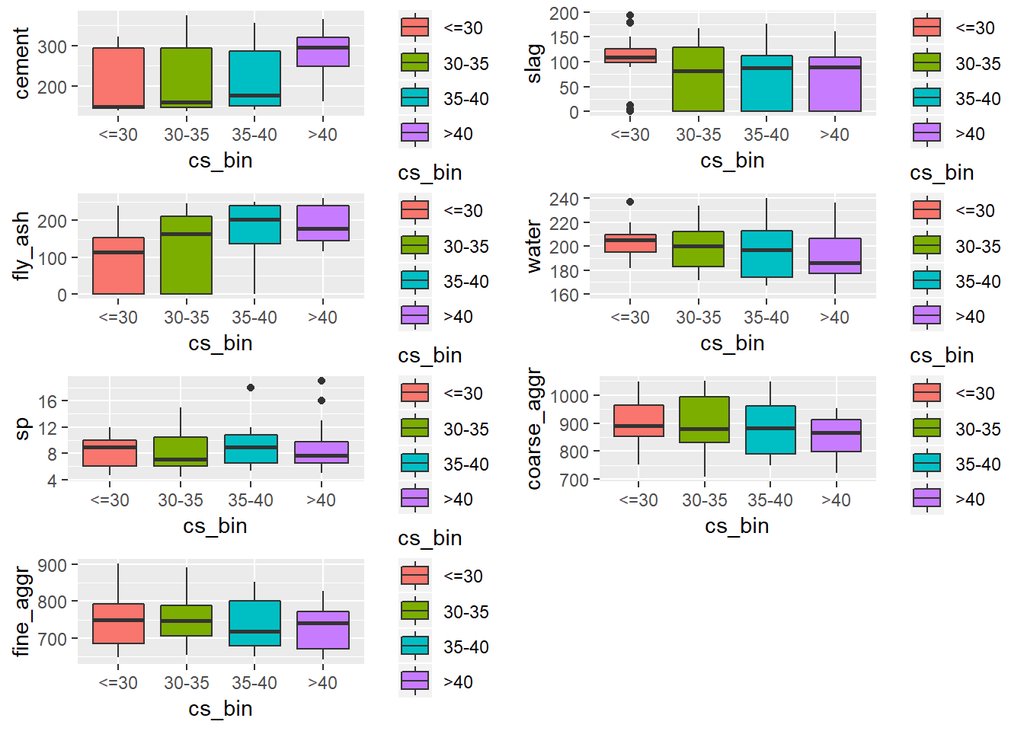

```r
# explore the association between CS and predictors
box = list()
box[[1]] = slump %>% ggplot(aes(x=cs_bin, y=cement)) +
  geom_boxplot(aes(fill = cs_bin))
box[[2]] = slump %>% ggplot(aes(x=cs_bin, y=slag)) + geom_boxplot(aes(fill = cs_bin))
box[[3]] = slump %>% ggplot(aes(x=cs_bin, y=fly_ash)) + geom_boxplot(aes(fill = cs_bin))
box[[4]] = slump %>% ggplot(aes(x=cs_bin, y=water)) + geom_boxplot(aes(fill = cs_bin))
box[[5]] = slump %>% ggplot(aes(x=cs_bin, y=sp)) + geom_boxplot(aes(fill = cs_bin))
box[[6]] = slump %>% ggplot(aes(x=cs_bin, y=coarse_aggr)) + geom_boxplot(aes(fill = cs_bin))
box[[7]] = slump %>% ggplot(aes(x=cs_bin, y=fine_aggr)) + geom_boxplot(aes(fill = cs_bin))

grid.arrange(grobs = box, ncol = 2)
```

- The first boxplot demonstrates the correlation between 28-day compressive strength and cement. As cement amount increases, the 28-day compressive strength increases though the variances of the cement are very large for the first few bins.
- Based on the observation, water and cement are two most predictive variables. In general, as water decreases, CS increases. And as cement increases, CS increases, though this might not be a linear relationship. When CS is larger than 40, its cement value becomes significantly higher. Other variables like fly_ash can also be good predictors.

### Decision tree model

```r
# prepare training, validation and test datasets
set.seed(100)
num_train = ceiling(103*0.8)
nrow_train = sample(1:nrow(slump), num_train)
slump_train = slump[nrow_train,]
slump_test = slump[-nrow_train,]

# build decision tree model
tree_fit = train(x = slump_train[,c(1,4)],
                 y = slump_train$compressive_strength,
                 method = 'rpart',
                 tuneLength = 5,
                 trControl = trainControl(method = 'cv', number = 10))
```

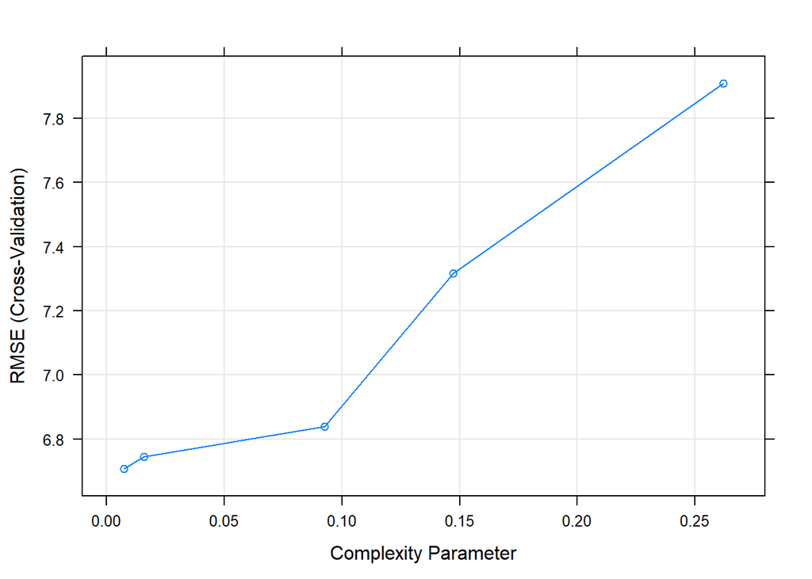

```r
plot(tree_fit)
```

```r
tree_fit
```

```
## CART
##
## 83 samples
##  2 predictor
##
## No pre-processing
## Resampling: Cross-Validated (10 fold)
## Summary of sample sizes: 74, 76, 74, 75, 75, 75, ...
## Resampling results across tuning parameters:
##
##   cp           RMSE      Rsquared    MAE
##   0.007566017  6.706835  0.34176291  5.171680
##   0.015923783  6.744449  0.33417249  5.283373
##   0.092709713  6.839885  0.31103899  5.683814
##   0.147347057  7.316363  0.25383474  5.932700
##   0.261900389  7.909197  0.08485282  6.624653
##
## RMSE was used to select the optimal model using the smallest value.
## The final value used for the model was cp = 0.007566017.
```

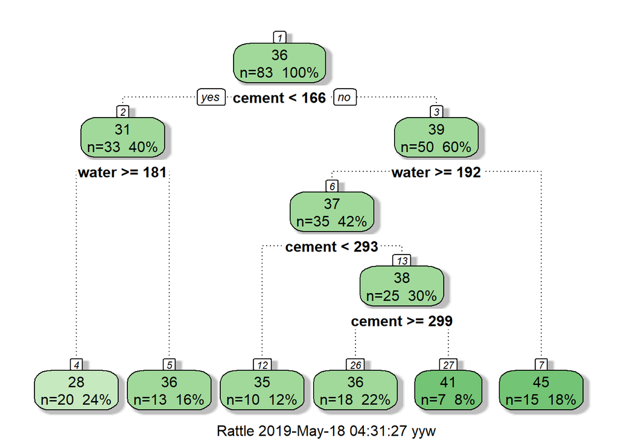

```r
# predict test data
pred_test = predict(tree_fit, slump_test)
rmse_test = sqrt(mean((pred_test - slump_test$compressive_strength)^2))
# plot the regression decision tree
fancyRpartPlot(tree_fit$finalModel)
```

- I trained a regression decision tree and used cross-validation on the training set to determine the optimal tree size by chosing the optimal parameters. The first plot shows the tuning results with 5 tuning parameters and the corresponding root mean square errors (RMSE). The second plot demonstrates how the best trained regression tree works. It demonstrates the cut point for each step and the counts and proportion for each decision.
- The root-mean-squared error (RMSE) is a measure of how well your model performed. It does this by measuring difference between predicted values and the actual values. Lower RMSE usually means better prediction performance on test data.
- The ideal depth of my final trained model is 5. It is controled by the complexity parameter, which can be selected by cross-validation.
- Accuracy score is used to measure the accuracy of a classification model, which is defined as the portion of correct predictions. My model is a regression model and it does not make sense to see accuracy of a regression model since predictions can hardly equal to the true value. The only way to calculate a meaningful accuracy score for a regression model is to stratify the output into bins and then treate the prediction as correct if it falls into the same bin as true value.

### Random forest

```r
# build random forest model and tune parameters mtry and number of trees
set.seed(100)
models = list()
tunegrid <- expand.grid(.mtry=c(1:7))
for (num_tree in c(100, 200, 300, 400, 500)){
  set.seed(100)
  rf_fit = train(x = slump_train[,-(8:11)],
                 y = slump_train$compressive_strength,
                 method = 'rf',
                 tuneGrid = tunegrid,
                 trControl = trainControl(method = 'cv', number = 10),
                 ntree = num_tree)
  models[[as.character(num_tree)]] = rf_fit
}


# compare results
results = NULL
for(i in names(models)){
  n_tree = as.numeric(i)
  s = models[[i]]
  model_s = s$results %>% mutate(ntree = n_tree)
  results = rbind(results,model_s)
}
results
```

```
##    mtry     RMSE  Rsquared      MAE    RMSESD RsquaredSD     MAESD ntree
## 1     1 4.851309 0.7613330 3.805970 1.2047170 0.13166290 1.0150830   100
## 2     2 3.971182 0.8389643 3.106691 1.3036139 0.10107969 1.0163719   100
## 3     3 3.711348 0.8564977 2.926222 1.0928658 0.05268878 0.9096147   100
## 4     4 3.469808 0.8676794 2.701847 1.1100618 0.05399895 0.8731433   100
## 5     5 3.381008 0.8702388 2.648072 1.1763297 0.06210015 0.8768461   100
## 6     6 3.373315 0.8611302 2.644444 1.0605858 0.05255381 0.7900445   100
## 7     7 3.302252 0.8578450 2.625201 0.8644330 0.07729100 0.6240505   100
## 8     1 4.865588 0.7722903 3.830315 1.1644163 0.12857301 0.9377055   200
## 9     2 3.988354 0.8437096 3.085503 1.2713956 0.10158331 0.9925129   200
## 10    3 3.675936 0.8620579 2.898543 1.0856550 0.06348595 0.8786763   200
## 11    4 3.425711 0.8723053 2.675312 1.1118658 0.05390696 0.8587171   200
## 12    5 3.429293 0.8620780 2.664139 1.0770152 0.06581792 0.8077713   200
## 13    6 3.311894 0.8685503 2.619189 1.0534613 0.05468054 0.7773229   200
## 14    7 3.294043 0.8605710 2.645319 0.8547803 0.06216750 0.6076227   200
```

[output cut: 21 more lines]

- The optimal number of trees are selected by cross-valiation (minimize the RMSE) with grid search of number of trees. The optimal random forest is reached by using 300 trees.
- The optimal number of features are selected by cross-valiation (minimize the RMSE) with grid search of features from 1 to 7. The optimal random forest is reached by using 7 features.

### Additional analyses

What alternative methods might you use to predict CS

- Instead of using random foreast, we can use Support Vector Regression, Neuron Network, eXtreme Gradient Boosting, K nearest neighbors, linear (or non-linear) regression with L1/L2 regularizations.

What additional data, not included in the dataset, might help better predict CS?

- I might be useful to create combination of predictors based on domain knowledge. In addition, According to Neela Deshpande et.al 2014, it might help better predict CS using other predictors such as Admixture (A) (kg/m3), Replacement ratio (RR) (%), and Water to total materials (W/T).

Based on the EDA you completed in the first step, what additional analyses might you complete based on the data structure?

- Since we can observe strong skewness of several input variables, I will log transform those input variables. In addition, I will normalize the input by mean and standard deviation.

What applications might your analysis lead to? In plain English, describe what business value these models could provide to a prospective client.

- It is common to have some requirements on 28 days of compressive strength in civil engineering. the random forest model we trained can predict (model) this compresive strength using the materials used in concrete, it can guide the production process and improve the product passing rate and thus reduce the cost. In addition, we can train a binary model where the output is wehether the product can pass the compressive strength test, and then use this model to guide the production process.